# Time dependent AUC with survival data _ correct6-2

Hwang Seong-Yun

2022 5 23

# Loading packages

```r
library(survival)
library(timeROC)
library(timereg)
library(ggplot2)
library(reshape)
library(plyr)
library(tidyverse)
library(coxed)
library(gridExtra)
```

# Generating simulation data from Cox Regression Model

## Background

- reference 1 : https://doi.org/10.5351/KJAS.2018.31.6.761
- reference 2 : https://doi.org/10.1017/psrm.2018.19

`-` Parametric basis distribution

- real survival time $Y$ : Exponential distribution
- censoring time $C$ : Uniform distribution
- $h(t|x)=h_{0}(t)exp(f(x))$
- $H(t|x)=\int_{0}^{t} h(s|x)ds= \int_{0}^{t} h_{0}(s)exp(f(x))ds=H_{0}(t)exp(f(x))$
- $h(t|x)=\frac {f(t|x)}{S(t|x)}= -\frac {d}{dt} log[S(t|x)]$
- $log[S(t|x)]= -\int_{0}^{t} h(s|x)ds= -H(t|x)= -H_{0}(t)exp(f(x))$
- $S(t|x)=exp[-H_{0}(t)exp(f(x))]$
- In general,…
- $F(t|x)=1-exp[-H_{0}(t) exp(f(x))]$
- -> $F^{-1}(t|x)=H_{0}^{-1}[-log(1-t) exp(-f(x))]$
- By Inverse Transform Sampling, suppose that $U_{1}, U_{2} \overset{i.i.d}{\sim}\ U(0,1)$, then we can generate real survival time $Y$ from Cox Regression Model using this equation.
- $Y=H_{Y0}^{-1}[-log(U_{1})exp(-f(x))]$
- And by assuming non-informative censoring, we can generate censoring time $C$ like this equation. (Set $Y$ and $C$ are independent each other.)
- $C=H_{C0}^{-1}[-log(U_{2})]$
- And set censoring indicator $\delta=I(Y \leq C)$ and observed survival time $T=min(Y,C)$
- $H_{Y0}(t)$ : Basis cumulative hazard function of real survival time $Y$
- $H_{C0}(t)$ : Basis cumulative hazard function of censoring time $C$
- When parametric basis distribution of real survival time $Y$ is Exponential distribution and parametric basis distribution of censoring time $C$ is Uniform distribution ($Y$ and $C$ are independent each other), then ~
- $Y$ : $f_{Y0}(t)=\lambda e^{-\lambda t}, t>0$ -> $S_{Y0}(t)=e^{-\lambda t}$ -> $h_{Y0}(t)=\lambda$
- $C$ : $f_{C0}(t)=\frac {1}{\lambda}, 0<t<\lambda$ -> $S_{C0}(t)=1-\frac {t}{\lambda}$ -> $h_{C0}(t)=\frac {1}{\lambda -t}$
- $\therefore Y=-\frac{1}{\lambda_{1}} log(U_{1}) exp(-f(x))$, $C=\lambda_{2}(1-U_{2})$

# Generate survival data with time dependent covariates

## Background

- reference 1 : https://doi.org/10.1002/sim.5452
- reference 2 : https://dx.doi.org/10.21037/atm.2018.02.12

## Case 1) Continuous time-varying covariate: exponential distribution of event times

- $Y$ : real survival time
- $C$ : censoring time
- model : $h(t,x,z(t))=h_{0}(t)exp(\beta x + \gamma z(t))$
- $Y$ : Assume $z(t)=\alpha t$, $\alpha > 0$
- $h_{0}(t)=\lambda$
- $h(t,x,z(t))=\lambda exp(\beta x + \gamma \alpha t)=-\frac{d}{dt} log[S(t,x,z(t))]$
- $log[S(t,x,z(t))]=-\int_{0}^{t}\lambda exp(\beta x + \gamma \alpha s)ds=-\frac{\lambda exp(\beta x)}{\gamma \alpha} [exp(\gamma \alpha t)-1]$
- $S(t,x,z(t))=exp[-\frac{\lambda exp(\beta x)}{\gamma \alpha} [exp(\gamma \alpha t)-1]]$
- $F(t,x,z(t))=1-exp[-\frac{\lambda exp(\beta x)}{\gamma \alpha} [exp(\gamma \alpha t)-1]]$
- $F^{-1}(t,x,z(t))=\frac {1}{\gamma \alpha} log[1-\frac {\gamma \alpha}{\lambda exp(\beta x)} log(1-t)]$
- $C$ : $f_{C0}(t)=\frac {1}{\lambda}, 0<t<\lambda$ -> $S_{C0}(t)=1-\frac {t}{\lambda}$ -> $h_{C0}(t)=\frac {1}{\lambda -t}$
- By Inverse Transform Sampling and non-informative censoring, suppose that $U_{1}, U_{2} \overset{i.i.d}{\sim}\ U(0,1)$, then we can generate real survival time $Y$ and censoring time $C$ like this.
- $\therefore Y=\frac {1}{\gamma \alpha} log[1-\frac {\gamma \alpha}{\lambda_{1} exp(\beta x)} log(U_{1})]$
- $\therefore C=\lambda_{2}(1-U_{2})$

## Generating simulation data

```r
lambda1 <- 0.003 # parameter for generate Y
lambda2 <- 0.2/lambda1 # parameter for generate C
beta0 <- 3 ; gamma0 <- 2 ; alpha0 <- 4 # true coefficients
Y <- c() # real survival time
C <- c() # censoring time
t <- c() # observed survival time
censor <- c() # censoring indicator
X <- c() # time invariant covariate
U1 <- c() # random variable from U(0,1) for generate Y
U2 <- c() # random variable from U(0,1) for generate C

for (i in 1:1000) {
  U1[i] <- runif(1)
  U2[i] <- runif(1)
  X[i] <- rnorm(1,mean=0,sd=1)
  Y[i] <- (1/gamma0*alpha0)*log(1-(gamma0*alpha0/lambda1/exp(beta0*X[i]))*log(U1[i]))
  C[i] <- (lambda2)*(1-U2[i])
  t[i] <- min(Y[i],C[i])
  censor[i] <- ifelse(Y[i]<=C[i],1,0)
}

mean(1-censor) # censoring rate
```

```
## [1] 0.223
```

```r
dt5 <- data.frame(X=X, Y=Y, C=C, time=t, censor=censor)
head(dt5,10)
```

```
##              X         Y         C      time censor
## 1   1.40815451  8.229759 26.272329  8.229759      1
## 2   1.36260417  6.657691 63.268227  6.657691      1
## 3   0.55474056 11.568984 47.595816 11.568984      1
## 4   0.05464969 14.450291 51.111131 14.450291      1
## 5  -0.29378678 11.778038 18.741086 11.778038      1
## 6   0.60451862  6.140991 27.775754  6.140991      1
## 7   0.64104896  9.185836 28.710542  9.185836      1
## 8   1.05912409 10.266578  2.781547  2.781547      0
## 9   1.11562941 10.663967 61.132973 10.663967      1
## 10 -0.46703164 18.668085 52.859234 18.668085      1
```

```r
min(dt5$time[dt5$censor==1])
```

```
## [1] 0.01476523
```

### Set Cox regression model

```r
cox.dep.dt5 <- coxph(Surv(time,censor) ~ X, data=dt5)
summary(cox.dep.dt5)
```

```
## Call:
## coxph(formula = Surv(time, censor) ~ X, data = dt5)
##
##   n= 1000, number of events= 777
##
##       coef exp(coef) se(coef)     z Pr(>|z|)
## X  3.04184  20.94385  0.09338 32.57   <2e-16 ***
## ---
## Signif. codes:  0 '***' 0.001 '**' 0.01 '*' 0.05 '.' 0.1 ' ' 1
##
##   exp(coef) exp(-coef) lower .95 upper .95
## X     20.94    0.04775     17.44     25.15
##
## Concordance= 0.88  (se = 0.006 )
## Likelihood ratio test= 1657  on 1 df,   p=<2e-16
## Wald test            = 1061  on 1 df,   p=<2e-16
## Score (logrank) test = 1175  on 1 df,   p=<2e-16
```

```r
risk.dep.dt5 <- predict(object=cox.dep.dt5, newdata=dt5, type="risk") # risk score
dt5$risk.dep.dt5 <- risk.dep.dt5
ROC.risk.dep.dt5 <- timeROC(T=dt5$time,
                         delta=dt5$censor,marker=dt5$risk.dep.dt5,
                         cause=1,weighting="marginal",
                         times=dt5$time)
ROC.risk.dep.dt5
```

```
## Time-dependent-Roc curve estimated using IPCW  (n=1000, without competing risks).
##                      Cases Survivors Censored AUC (%)
## t=0.0147652310105795     0       999        1      NA
## t=8.19210756232468     140       749      111   93.70
## t=12.5755154294904     334       500      166   93.71
## t=17.4164065936493     549       250      201   96.16
## t=32.5571573654888     776         0      224      NA
##
## Method used for estimating IPCW:marginal
##
## Total computation time : 0.47  secs.
```

#### Make AUC data

```r
# uncensored
uncensored.density5 <- density(dt5$time[dt5$censor==1])
data5_1 <- data.frame(time=uncensored.density5[["x"]],
                    density=uncensored.density5[["y"]])
data5_1$density.adjusted <- (max(na.omit(ROC.risk.dep.dt5[["AUC"]]))-min(na.omit(ROC.risk.dep.dt5[["AUC"]])))*(uncensored.density5[["y"]]-min(uncensored.density5[["y"]]))/(max(uncensored.density5[["y"]])-min(uncensored.density5[["y"]]))+min(na.omit(ROC.risk.dep.dt5[["AUC"]]))

# censored
censored.density5 <- density(dt5$time[dt5$censor==0])
data5_2 <- data.frame(time=censored.density5[["x"]],
                    density=censored.density5[["y"]])
data5_2$density.adjusted <- (max(na.omit(ROC.risk.dep.dt5[["AUC"]]))-min(na.omit(ROC.risk.dep.dt5[["AUC"]])))*(censored.density5[["y"]]-min(censored.density5[["y"]]))/(max(censored.density5[["y"]])-min(censored.density5[["y"]]))+min(na.omit(ROC.risk.dep.dt5[["AUC"]]))

res5 <- data.frame(time=ROC.risk.dep.dt5[["times"]],
                    cox.dep.dt5=ROC.risk.dep.dt5[["AUC"]])
res5 <- melt(data = res5,
                   id.vars = "time",
                   measure.vars = c("cox.dep.dt5"))
```

#### Time dependent AUC plot with ggplot2 (cox.dep.dt5)

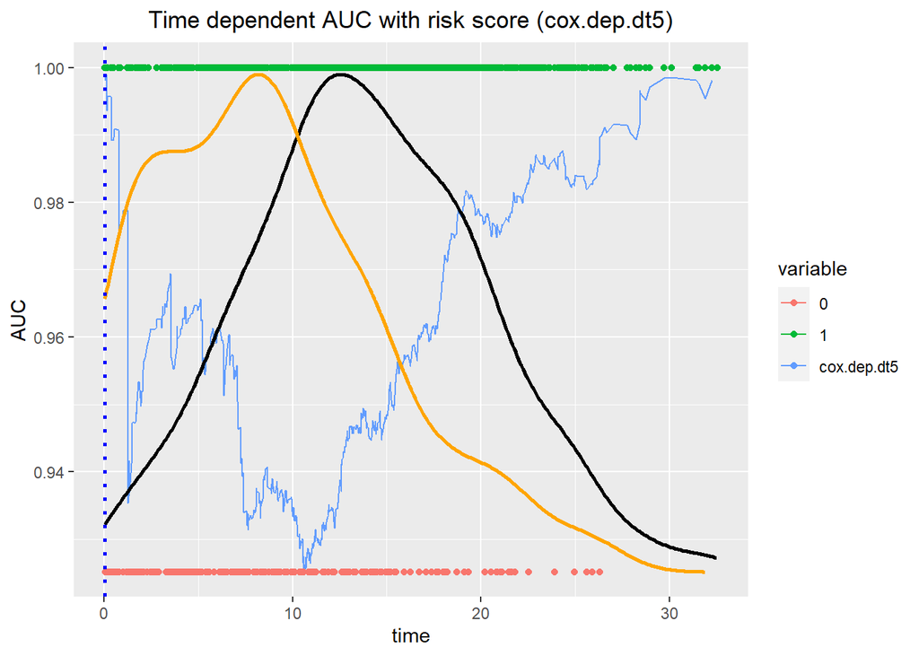

```r
dt5$censor1 <- ifelse(dt5$censor==1,
                    1,min(na.omit(ROC.risk.dep.dt5[["AUC"]])))
ggplot() +
  geom_line(data=res5, aes(x=time, y=value,
                            group=variable, color=variable)) +
  geom_point(data=dt5, aes(x=time, y=censor1, color=as.factor(censor))) +
  geom_line(data=data5_1, aes(x=time, y=density.adjusted),
            size=1, colour='black') +
  geom_line(data=data5_2, aes(x=time, y=density.adjusted),
            size=1, colour='orange') +
  scale_x_continuous(limits = c(0, max(dt5$time))) +
  geom_vline(xintercept = min(dt5$time[dt5$censor==1]),
             linetype="dotted", color = "blue", size=1) +
  ggtitle("Time dependent AUC with risk score (cox.dep.dt5)") +
  xlab("time") + ylab("AUC") +
  theme(plot.title = element_text(hjust = 0.5))
```

#### Mean value of Time dependent AUC (cox.dep.dt5)

```r
mean(ROC.risk.dep.dt5[["AUC"]],na.rm=TRUE)
```

```
## [1] 0.9550931
```

#### simulation (repeat 100 times / time VS mean of AUC)

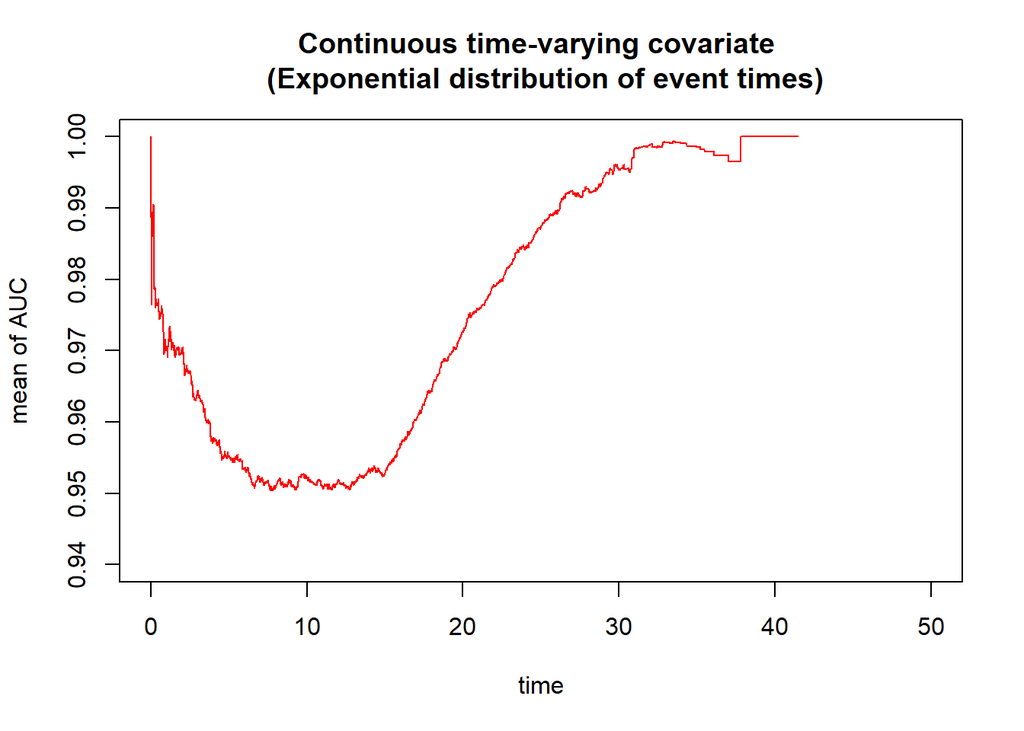

```r
con.AUC <- matrix(nrow=length(seq(0,50,0.01)),ncol=100)

for (i in 1:100) {

  lambda1 <- 0.003 # parameter for generate Y
  lambda2 <- 0.2/lambda1 # parameter for generate C
  beta0 <- 3 ; gamma0 <- 2 ; alpha0 <- 4 # true coefficients
  Y <- c() # real survival time
  C <- c() # censoring time
  t <- c() # observed survival time
  censor <- c() # censoring indicator
  X <- c() # time invariant covariate
  U1 <- c() # random variable from U(0,1) for generate Y
  U2 <- c() # random variable from U(0,1) for generate C

  # Generate simulation data
  set.seed(i)
  for (j in 1:200) {
    U1[j] <- runif(1)
    U2[j] <- runif(1)
    X[j] <- rnorm(1,mean=0,sd=1)
    Y[j] <- (1/gamma0*alpha0)*log(1-(gamma0*alpha0/lambda1/exp(beta0*X[j]))*log(U1[j]))
    C[j] <- (lambda2)*(1-U2[j])
    t[j] <- min(Y[j],C[j])
    censor[j] <- ifelse(Y[j]<=C[j],1,0)
  }
  dt5 <- data.frame(X=X, Y=Y, C=C, time=t, censor=censor)

  # Set Cox regression model
  cox.dep.dt5 <- coxph(Surv(time,censor) ~ X, data=dt5)
  summary(cox.dep.dt5)
  risk.dep.dt5 <- predict(object=cox.dep.dt5, newdata=dt5, type="risk") # risk score
  dt5$risk.dep.dt5 <- risk.dep.dt5
  ROC.risk.dep.dt5 <- timeROC(T=dt5$time,
                           delta=dt5$censor,marker=dt5$risk.dep.dt5,
                           cause=1,weighting="marginal",
                           times=seq(0,50,0.01))

  con.AUC[,i] <- ROC.risk.dep.dt5[["AUC"]]

  # print(i)

}

dat5 <- data.frame(time=seq(0,50,0.01), con.AUC=rowMeans(con.AUC, na.rm=TRUE))
plot(x=dat5$time, y=dat5$con.AUC, xlab="time", ylab="mean of AUC",
     main="Continuous time-varying covariate \n (Exponential distribution of event times)", type="l", col="red", ylim=c(0.94,1))
```

## Case 2) Dichotomous time-varying covariate: exponential distribution of event times

- $Y$ : real survival time
- $C$ : censoring time
- model : $h(t,x,z(t))=h_{0}(t)exp(\beta x + \gamma z(t))$
- $Y$ : Assume $z(t)=\begin{cases} 0, & \mbox{if } t<t_{0} \\ 1, & \mbox{if } t \geq t_{0} \end{cases}$
- $h_{0}(t)=\lambda$
- If $t<t_{0}$, then $H(t,x,z(t))=\int_{0}^{t}h_{0}(s)exp(\gamma z(s) + \beta x)ds=\int_{0}^{t}\lambda exp(\beta x)ds=\lambda exp(\beta x)t$
- If $t \geq t_{0}$, then $H(t,x,z(t))=\int_{0}^{t}h_{0}(s)exp(\gamma z(s) + \beta x)ds=\int_{0}^{t} \lambda exp(\gamma z(s) + \beta x)ds=\lambda exp(\beta x) \int_{0}^{t}exp(\gamma z(s))ds=\lambda exp(\beta x) [ \int_{0}^{t_{0}}ds+\int_{t_{0}}^{t}exp(\gamma)ds ]=\lambda exp(\beta x)[t_{0}+exp(\gamma)t - exp(\gamma) t_{0}]$
- Hence, $H^{-1}(t,x,z(t))=\begin{cases} \frac {t}{\lambda exp(\beta x)}, & \mbox{if } t < \lambda exp(\beta x)t_{0} \\ \frac {t - \lambda exp(\beta x)t_{0} + \lambda exp(\beta x + \gamma)t_{0}}{\lambda exp(\beta x + \gamma)}, & \mbox{if } t \geq \lambda exp(\beta x)t_{0} \end{cases}$
- Therefore, $T=\begin{cases} \frac {-log(U)}{\lambda exp(\beta x)}, & \mbox{if } -log(U) < \lambda exp(\beta x)t_{0} \\ \frac {-log(U) - \lambda exp(\beta x)t_{0} + \lambda exp(\beta x + \gamma)t_{0}}{\lambda exp(\beta x + \gamma)}, & \mbox{if } -log(U) \geq \lambda exp(\beta x)t_{0} \end{cases}$ when $U \sim U(0,1)$
- $C$ : $f_{C0}(t)=\frac {1}{\lambda}, 0<t<\lambda$ -> $S_{C0}(t)=1-\frac {t}{\lambda}$ -> $h_{C0}(t)=\frac {1}{\lambda -t}$
- By Inverse Transform Sampling and non-informative censoring, suppose that $U_{1}, U_{2} \overset{i.i.d}{\sim}\ U(0,1)$, then we can generate real survival time $Y$ and censoring time $C$ like this.
- $\therefore Y=\begin{cases} \frac {-log(U_{1})}{\lambda exp(\beta x)}, & \mbox{if } -log(U_{1}) < \lambda exp(\beta x)t_{0} \\ \frac {-log(U_{1}) - \lambda exp(\beta x)t_{0} + \lambda exp(\beta x + \gamma)t_{0}}{\lambda exp(\beta x + \gamma)}, & \mbox{if } -log(U_{1}) \geq \lambda exp(\beta x)t_{0} \end{cases}$
- $\therefore C=\lambda_{2}(1-U_{2})$

## Generating simulation data

```r
lambda1 <- 0.003 # parameter for generate Y
lambda2 <- 0.2/lambda1 # parameter for generate C
beta0 <- 3 ; gamma0 <- 2 # true coefficients
t0 <- 30 # denote the time at which the time-varying covariate changes from unexposed (Z(t) = 0) to exposed (Z(t) = 1)
Y <- c() # real survival time
C <- c() # censoring time
t <- c() # observed survival time
censor <- c() # censoring indicator
X <- c() # time invariant covariate
U1 <- c() # random variable from U(0,1) for generate Y
U2 <- c() # random variable from U(0,1) for generate C

for (i in 1:1000) {
  U1[i] <- runif(1)
  U2[i] <- runif(1)
  X[i] <- rnorm(1,mean=0,sd=1)
  Y[i] <- ifelse(-log(U1[i])<lambda1*exp(beta0*X[i])*t0, -log(U1[i])/lambda1/exp(beta0*X[i]), (-log(U1[i])-lambda1*exp(beta0*X[i])*t0+lambda1*exp(beta0*X[i]+gamma0)*t0)/lambda1/exp(beta0*X[i]+gamma0))
  C[i] <- (lambda2)*(1-U2[i])
  t[i] <- min(Y[i],C[i])
  censor[i] <- ifelse(Y[i]<=C[i],1,0)
}

mean(1-censor) # censoring rate
```

```
## [1] 0.631
```

```r
dt6 <- data.frame(X=X, Y=Y, C=C, time=t, censor=censor)
head(dt6,10)
```

```
##             X          Y         C      time censor
## 1  -0.1417817  185.27626 51.337728 51.337728      0
## 2  -1.0400575  105.71744 63.702878 63.702878      0
## 3   1.0947738   23.44879 11.668880 11.668880      0
## 4  -1.0465768 4002.45259  0.137130  0.137130      0
## 5   0.6086025   12.13694 43.728973 12.136936      1
## 6   0.1727104   29.75341 39.518437 29.753412      1
## 7  -0.2172085   31.73264 10.186662 10.186662      0
## 8  -0.3577165  129.28214  6.415028  6.415028      0
## 9  -2.0129442 8822.30925 19.100867 19.100867      0
## 10 -0.9321912  632.05434 29.483860 29.483860      0
```

```r
min(dt6$time[dt6$censor==1])
```

```
## [1] 0.00337523
```

### Set Cox regression model

```r
cox.dep.dt6 <- coxph(Surv(time,censor) ~ X, data=dt6)
summary(cox.dep.dt6)
```

```
## Call:
## coxph(formula = Surv(time, censor) ~ X, data = dt6)
##
##   n= 1000, number of events= 369
##
##      coef exp(coef) se(coef)    z Pr(>|z|)
## X  2.9459   19.0283   0.1164 25.3   <2e-16 ***
## ---
## Signif. codes:  0 '***' 0.001 '**' 0.01 '*' 0.05 '.' 0.1 ' ' 1
##
##   exp(coef) exp(-coef) lower .95 upper .95
## X     19.03    0.05255     15.15     23.91
##
## Concordance= 0.91  (se = 0.006 )
## Likelihood ratio test= 1054  on 1 df,   p=<2e-16
## Wald test            = 640.3  on 1 df,   p=<2e-16
## Score (logrank) test = 757.2  on 1 df,   p=<2e-16
```

```r
risk.dep.dt6 <- predict(object=cox.dep.dt6, newdata=dt6, type="risk") # risk score
dt6$risk.dep.dt6 <- risk.dep.dt6
ROC.risk.dep.dt6 <- timeROC(T=dt6$time,
                         delta=dt6$censor,marker=dt6$risk.dep.dt6,
                         cause=1,weighting="marginal",
                         times=dt6$time)
ROC.risk.dep.dt6
```

```
## Time-dependent-Roc curve estimated using IPCW  (n=1000, without competing risks).
##                       Cases Survivors Censored AUC (%)
## t=0.00337522975378996     0       999        1      NA
## t=6.68620392680168      155       749       96   95.35
## t=22.6881145344426      232       500      268   94.93
## t=38.4072531169901      332       250      418   93.31
## t=66.6533965927859      369         0      631      NA
##
## Method used for estimating IPCW:marginal
##
## Total computation time : 0.43  secs.
```

#### Make AUC data

```r
# uncensored
uncensored.density6 <- density(dt6$time[dt6$censor==1])
data6_1 <- data.frame(time=uncensored.density6[["x"]],
                    density=uncensored.density6[["y"]])
data6_1$density.adjusted <- (max(na.omit(ROC.risk.dep.dt6[["AUC"]]))-min(na.omit(ROC.risk.dep.dt6[["AUC"]])))*(uncensored.density6[["y"]]-min(uncensored.density6[["y"]]))/(max(uncensored.density6[["y"]])-min(uncensored.density6[["y"]]))+min(na.omit(ROC.risk.dep.dt6[["AUC"]]))

# censored
censored.density6 <- density(dt6$time[dt6$censor==0])
data6_2 <- data.frame(time=censored.density6[["x"]],
                    density=censored.density6[["y"]])
data6_2$density.adjusted <- (max(na.omit(ROC.risk.dep.dt6[["AUC"]]))-min(na.omit(ROC.risk.dep.dt6[["AUC"]])))*(censored.density6[["y"]]-min(censored.density6[["y"]]))/(max(censored.density6[["y"]])-min(censored.density6[["y"]]))+min(na.omit(ROC.risk.dep.dt6[["AUC"]]))

res6 <- data.frame(time=ROC.risk.dep.dt6[["times"]],
                    cox.dep.dt6=ROC.risk.dep.dt6[["AUC"]])
res6 <- melt(data = res6,
                   id.vars = "time",
                   measure.vars = c("cox.dep.dt6"))
```

#### Time dependent AUC plot with ggplot2 (cox.dep.dt6)

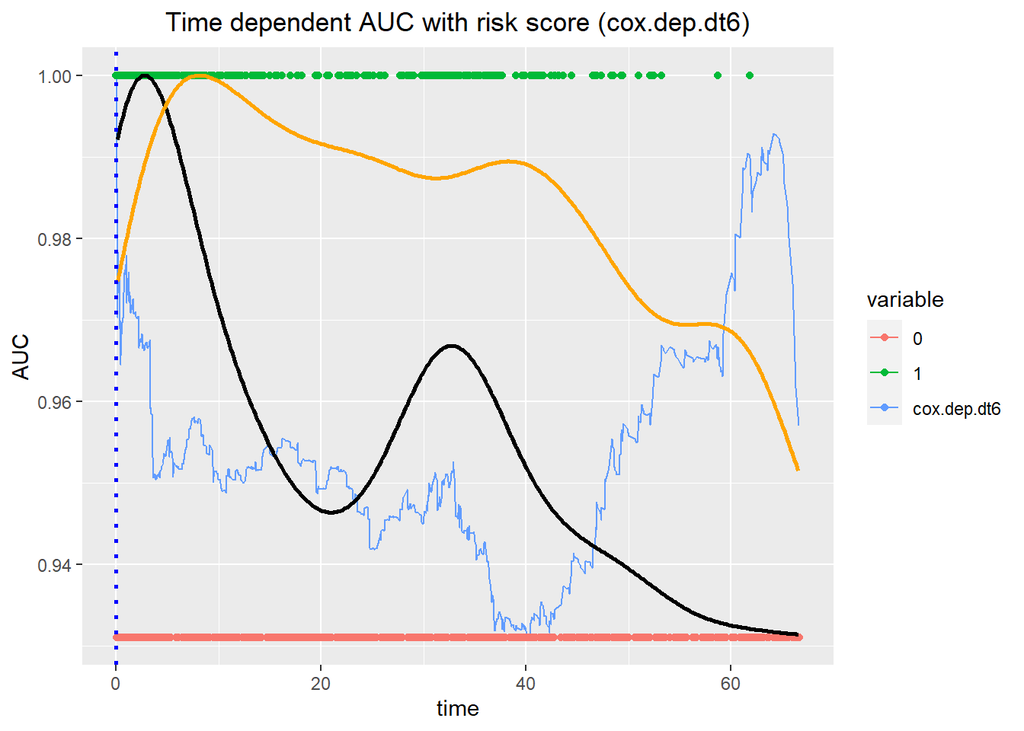

```r
dt6$censor1 <- ifelse(dt6$censor==1,
                    1,min(na.omit(ROC.risk.dep.dt6[["AUC"]])))
ggplot() +
  geom_line(data=res6, aes(x=time, y=value,
                            group=variable, color=variable)) +
  geom_point(data=dt6, aes(x=time, y=censor1, color=as.factor(censor))) +
  geom_line(data=data6_1, aes(x=time, y=density.adjusted),
            size=1, colour='black') +
  geom_line(data=data6_2, aes(x=time, y=density.adjusted),
            size=1, colour='orange') +
  scale_x_continuous(limits = c(0, max(dt6$time))) +
  geom_vline(xintercept = min(dt6$time[dt6$censor==1]),
             linetype="dotted", color = "blue", size=1) +
  ggtitle("Time dependent AUC with risk score (cox.dep.dt6)") +
  xlab("time") + ylab("AUC") +
  theme(plot.title = element_text(hjust = 0.5))
```

#### Mean value of Time dependent AUC (cox.dep.dt6)

```r
mean(ROC.risk.dep.dt6[["AUC"]],na.rm=TRUE)
```

```
## [1] 0.9544723
```

#### simulation (repeat 100 times / time VS mean of AUC)

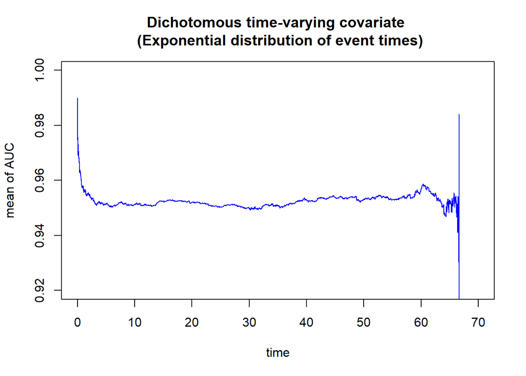

```r
din.AUC <- matrix(nrow=length(seq(0,70,0.01)),ncol=100)

for (i in 1:100) {

  lambda1 <- 0.003 # parameter for generate Y
  lambda2 <- 0.2/lambda1 # parameter for generate C
  beta0 <- 3 ; gamma0 <- 2 # true coefficients
  t0 <- 30 # denote the time at which the time-varying covariate changes from unexposed (Z(t) = 0) to exposed (Z(t) = 1)
  Y <- c() # real survival time
  C <- c() # censoring time
  t <- c() # observed survival time
  censor <- c() # censoring indicator
  X <- c() # time invariant covariate
  U1 <- c() # random variable from U(0,1) for generate Y
  U2 <- c() # random variable from U(0,1) for generate C

  # Generate simulation data
  set.seed(i)
  for (j in 1:200) {
    U1[j] <- runif(1)
    U2[j] <- runif(1)
    X[j] <- rnorm(1,mean=0,sd=1)
    Y[j] <- ifelse(-log(U1[j])<lambda1*exp(beta0*X[j])*t0, -log(U1[j])/lambda1/exp(beta0*X[j]), (-log(U1[j])-lambda1*exp(beta0*X[j])*t0+lambda1*exp(beta0*X[j]+gamma0)*t0)/lambda1/exp(beta0*X[j]+gamma0))
    C[j] <- (lambda2)*(1-U2[j])
    t[j] <- min(Y[j],C[j])
    censor[j] <- ifelse(Y[j]<=C[j],1,0)
  }
  dt6 <- data.frame(X=X, Y=Y, C=C, time=t, censor=censor)

  # Set Cox regression model
  cox.dep.dt6 <- coxph(Surv(time,censor) ~ X, data=dt6)
  summary(cox.dep.dt6)
  risk.dep.dt6 <- predict(object=cox.dep.dt6, newdata=dt6, type="risk") # risk score
  dt6$risk.dep.dt6 <- risk.dep.dt6
  ROC.risk.dep.dt6 <- timeROC(T=dt6$time,
                           delta=dt6$censor,marker=dt6$risk.dep.dt6,
                           cause=1,weighting="marginal",
                           times=seq(0,70,0.01))

  din.AUC[,i] <- ROC.risk.dep.dt6[["AUC"]]

  # print(i)

}

dat6 <- data.frame(time=seq(0,70,0.01), din.AUC=rowMeans(din.AUC, na.rm=TRUE))
plot(x=dat6$time, y=dat6$din.AUC, xlab="time", ylab="mean of AUC",
     main="Dichotomous time-varying covariate \n (Exponential distribution of event times)", type="l", col="blue", ylim=c(0.92,1))
```